# Análises avançadas e auditoria inferencial

## Escopo e salvaguardas

Esta camada é adicional à análise descritiva. Os testes são exploratórios e não demonstram causalidade. SIH e SIM são analisados como fontes independentes, sem pareamento, junção ou correlação entre registros ou agregados dos dois sistemas.

Foram utilizados testes de Mann–Kendall, Kruskal–Wallis, Dunn com Bonferroni, qui-quadrado de Pearson ou Monte Carlo quando os valores esperados não atendiam ao critério predefinido e V de Cramér corrigido. Resultados múltiplos incluem correções BH e/ou Bonferroni, conforme a família de hipóteses.

## Tendências temporais

```
##
##
## |serie                           |periodicidade |  n|    tau| p_valor| sen_slope|  p_bh|
## |:-------------------------------|:-------------|--:|------:|-------:|---------:|-----:|
## |SIH: internações                |anual         | 16|  0.767|   0.000|   517.375| 0.000|
## |SIH: óbitos hospitalares        |anual         | 16|  0.750|   0.000|    83.500| 0.000|
## |SIH: mortalidade hospitalar (%) |anual         | 16| -0.333|   0.079|    -0.085| 0.090|
## |SIH: permanência média          |anual         | 16| -0.933|   0.000|    -0.510| 0.000|
## |SIH: custo médio nominal        |anual         | 16|  0.650|   0.001|    39.749| 0.001|
## |SIM: óbitos                     |anual         | 15| -0.124|   0.553|   -17.333| 0.553|
## |SIH: taxa de internação         |anual         | 15|  0.676|   0.001|     2.182| 0.001|
## |SIM: taxa de mortalidade        |anual         | 14| -0.451|   0.029|    -0.646| 0.038|
```

```
##
##
## |serie                   |periodicidade  |   n|    tau| p_valor| p_bonferroni|
## |:-----------------------|:--------------|---:|------:|-------:|------------:|
## |SIH_internacoes         |mensal sazonal | 192|  0.705|   0.000|        0.000|
## |SIM_obitos_causa_basica |mensal sazonal | 180| -0.075|   0.179|        0.358|
```

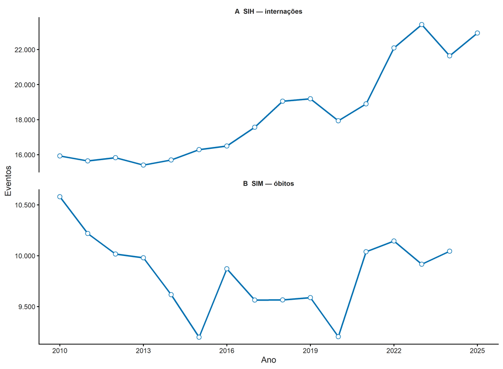

O teste identifica monotonicidade, não pontos de quebra nem mecanismos causais. A inclinação de Sen é apresentada na unidade original de cada indicador por ano.

## Evolução espacial e sazonalidade

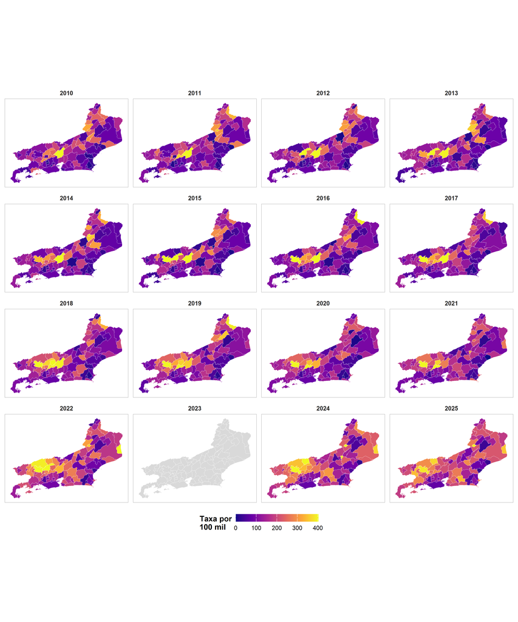

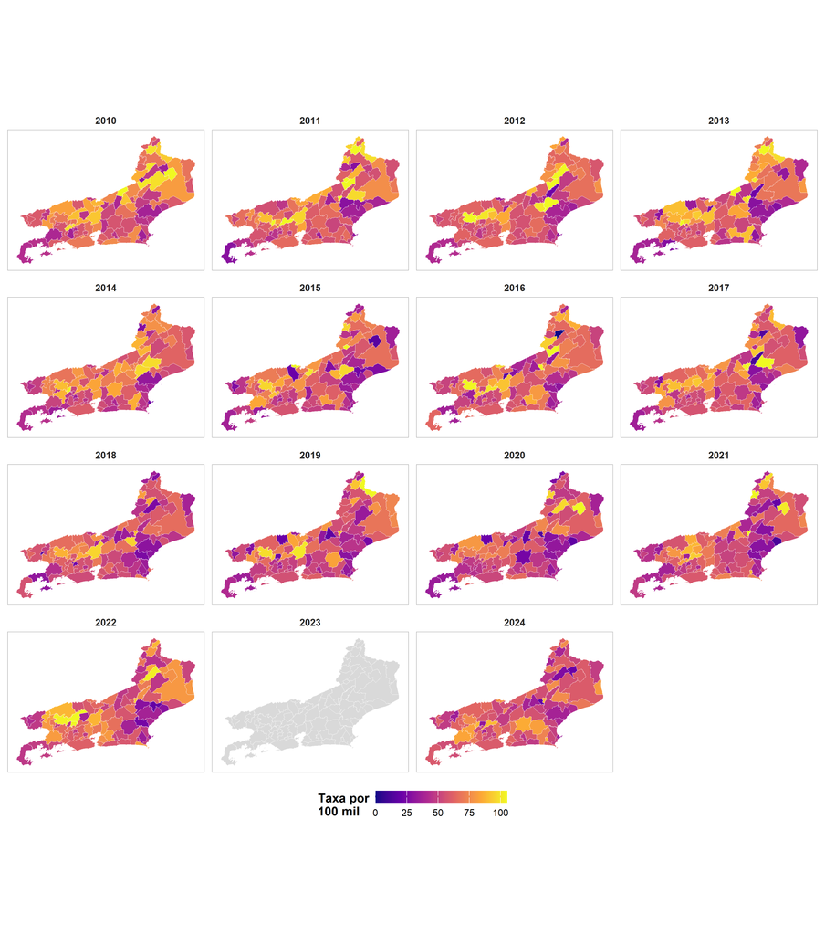

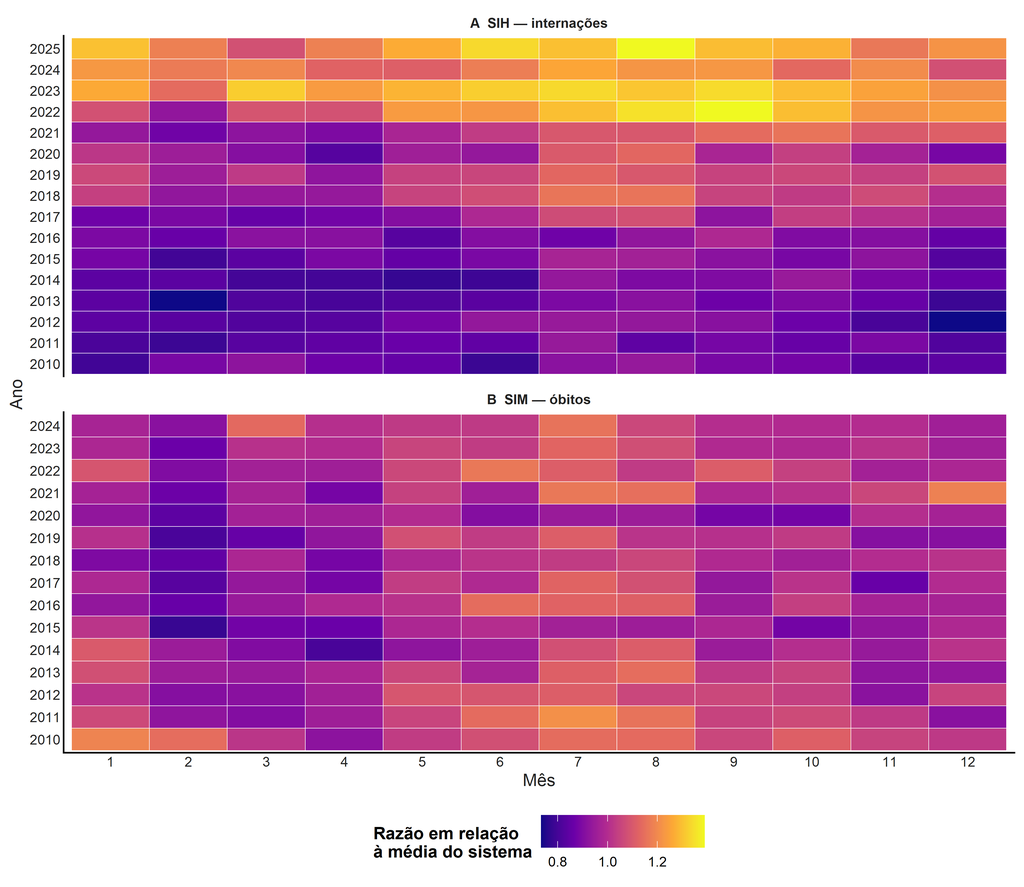

As malhas municipais são do `geobr` 2.0.1, ano 2020, SIRGAS 2000. O painel de 2023 sem preenchimento representa ausência de denominador compatível, não taxa zero. A escala espacial é mantida comum entre anos dentro de cada sistema.

## Diferenças inter-regionais

```
##
##
## |sistema |  ano|  n| regioes| estatistica| graus_liberdade| p_valor| p_bonferroni_entre_anos|
## |:-------|----:|--:|-------:|-----------:|---------------:|-------:|-----------------------:|
## |SIH     | 2010| 92|       9|      33.840|               8|   0.000|                   0.001|
## |SIH     | 2011| 92|       9|      30.492|               8|   0.000|                   0.003|
## |SIH     | 2012| 92|       9|      31.302|               8|   0.000|                   0.002|
## |SIH     | 2013| 92|       9|      34.659|               8|   0.000|                   0.000|
## |SIH     | 2014| 92|       9|      28.951|               8|   0.000|                   0.005|
## |SIH     | 2015| 92|       9|      30.934|               8|   0.000|                   0.002|
## |SIH     | 2016| 92|       9|      27.696|               8|   0.001|                   0.008|
## |SIH     | 2017| 92|       9|      30.415|               8|   0.000|                   0.003|
## |SIH     | 2018| 92|       9|      27.094|               8|   0.001|                   0.010|
## |SIH     | 2019| 92|       9|      32.802|               8|   0.000|                   0.001|
## |SIH     | 2020| 92|       9|      29.247|               8|   0.000|                   0.004|
## |SIH     | 2021| 92|       9|      19.280|               8|   0.013|                   0.201|
## |SIH     | 2022| 92|       9|      20.203|               8|   0.010|                   0.144|
## |SIH     | 2024| 92|       9|      27.132|               8|   0.001|                   0.010|
## |SIH     | 2025| 92|       9|      27.958|               8|   0.000|                   0.007|
## |SIM     | 2010| 92|       9|      10.776|               8|   0.215|                   1.000|
## |SIM     | 2011| 92|       9|      23.119|               8|   0.003|                   0.045|
## |SIM     | 2012| 92|       9|      23.153|               8|   0.003|                   0.044|
## |SIM     | 2013| 92|       9|      22.967|               8|   0.003|                   0.048|
## |SIM     | 2014| 92|       9|      24.990|               8|   0.002|                   0.022|
## |SIM     | 2015| 92|       9|      19.302|               8|   0.013|                   0.187|
## |SIM     | 2016| 92|       9|       7.318|               8|   0.503|                   1.000|
## |SIM     | 2017| 92|       9|      22.162|               8|   0.005|                   0.065|
## |SIM     | 2018| 92|       9|      12.693|               8|   0.123|                   1.000|
## |SIM     | 2019| 92|       9|      10.192|               8|   0.252|                   1.000|
## |SIM     | 2020| 92|       9|      11.631|               8|   0.168|                   1.000|
## |SIM     | 2021| 92|       9|       7.358|               8|   0.499|                   1.000|
## |SIM     | 2022| 92|       9|      16.551|               8|   0.035|                   0.492|
## |SIM     | 2024| 92|       9|       6.816|               8|   0.557|                   1.000|
```

```
##
##
## |sistema |  ano|comparacao                            |      z| p_valor| p_bonferroni| p_bonferroni_global|
## |:-------|----:|:-------------------------------------|------:|-------:|------------:|-------------------:|
## |SIH     | 2013|Médio Paraíba - Metropolitana I       | -3.279|   0.001|        0.037|               1.000|
## |SIH     | 2013|Médio Paraíba - Norte                 | -4.600|   0.000|        0.000|               0.004|
## |SIH     | 2020|Baía da Ilha Grande - Metropolitana I | -3.399|   0.001|        0.024|               0.706|
## |SIM     | 2014|Baía da Ilha Grande - Serrana         | -3.222|   0.001|        0.046|               1.000|
## |SIM     | 2014|Metropolitana I - Serrana             | -3.434|   0.001|        0.021|               0.621|
## |SIM     | 2017|Baixada Litorânea - Centro-Sul        | -3.659|   0.000|        0.009|               0.264|
## |SIM     | 2017|Centro-Sul - Norte                    |  3.257|   0.001|        0.041|               1.000|
## |SIM     | 2017|Centro-Sul - Serrana                  |  3.783|   0.000|        0.006|               0.161|
```

Kruskal–Wallis foi aplicado separadamente por ano, usando os municípios como unidades. A coluna de Bonferroni entre anos controla a multiplicidade da série de testes globais. O pós-teste de Dunn controla as 36 comparações regionais de cada ano; uma coluna adicional aplica Bonferroni a todas as comparações conjuntamente.

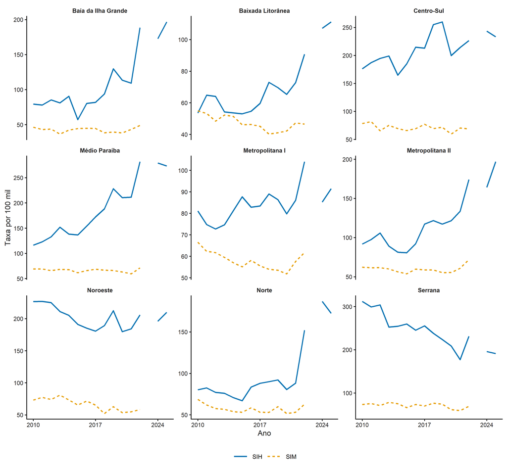

## Associação com óbito hospitalar

```
##
##
## |variavel        |      n| linhas| colunas|metodo                              | estatistica| graus_liberdade| p_valor| cramer_v_corrigido| expected_min| expected_below_5_pct| simulacoes| p_bh| p_bonferroni|
## |:---------------|------:|------:|-------:|:-----------------------------------|-----------:|---------------:|-------:|------------------:|------------:|--------------------:|----------:|----:|------------:|
## |sexo            | 292952|      2|       2|Qui-quadrado de Pearson assintótico |      78.354|               1|       0|              0.016|    27253.761|                0.000|          0|    0|            0|
## |faixa_etaria    | 292952|      6|       2|Qui-quadrado de Pearson assintótico |    3109.293|               5|       0|              0.103|       47.157|                0.000|          0|    0|            0|
## |raca_cor_rotulo | 292952|      6|       2|Qui-quadrado de Pearson assintótico |    2156.552|               5|       0|              0.086|        2.706|                8.333|          0|    0|            0|
## |carater_rotulo  | 292952|      2|       2|Qui-quadrado de Pearson assintótico |    3830.017|               1|       0|              0.114|     9453.856|                0.000|          0|    0|            0|
## |regiao_saude    | 292952|      9|       2|Qui-quadrado de Pearson assintótico |    4592.189|               8|       0|              0.125|      950.295|                0.000|          0|    0|            0|
## |subgrupo_cid    | 292952|     10|       2|Qui-quadrado de Pearson assintótico |    8885.056|               9|       0|              0.174|        8.504|                0.000|          0|    0|            0|
## |periodo         | 292952|      4|       2|Qui-quadrado de Pearson assintótico |     126.458|               3|       0|              0.021|    11347.874|                0.000|          0|    0|            0|
```

Os testes incluíram categorias ignoradas como categoria explícita para não ocultar o padrão de ausência. Valores de *p* muito pequenos devem ser interpretados junto ao V de Cramér, pois o grande tamanho amostral detecta associações de magnitude reduzida. Não houve necessidade de Monte Carlo na base real porque as tabelas atenderam ao critério dos valores esperados; o caminho de Monte Carlo permanece implementado e testado com dados sintéticos.

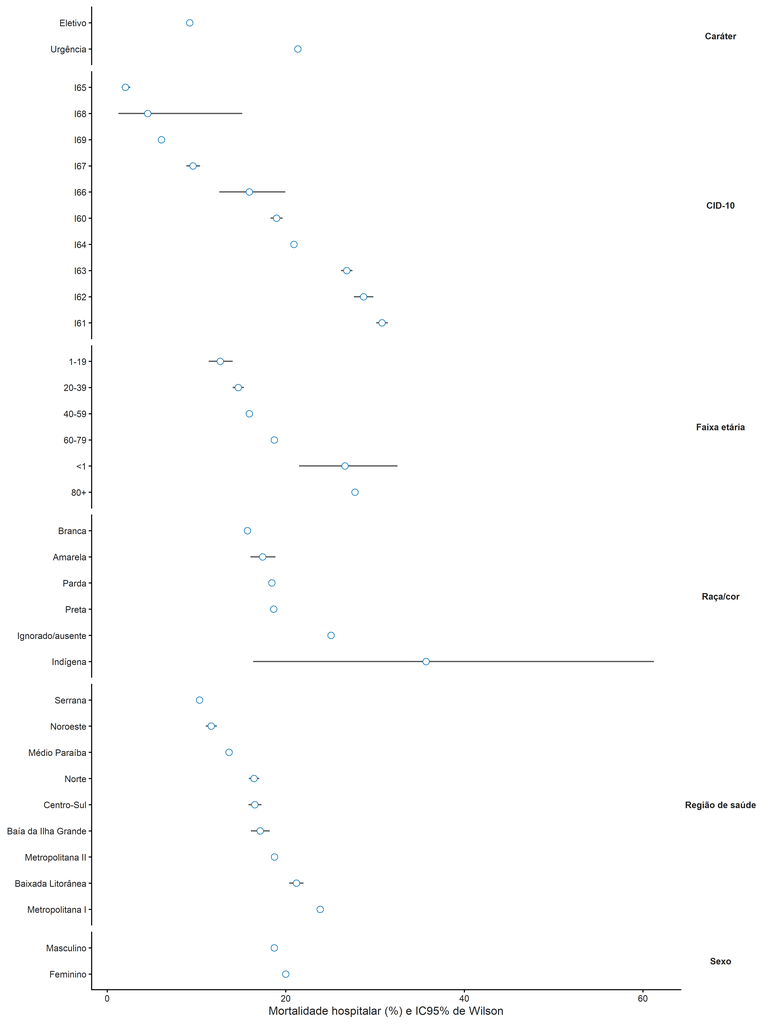

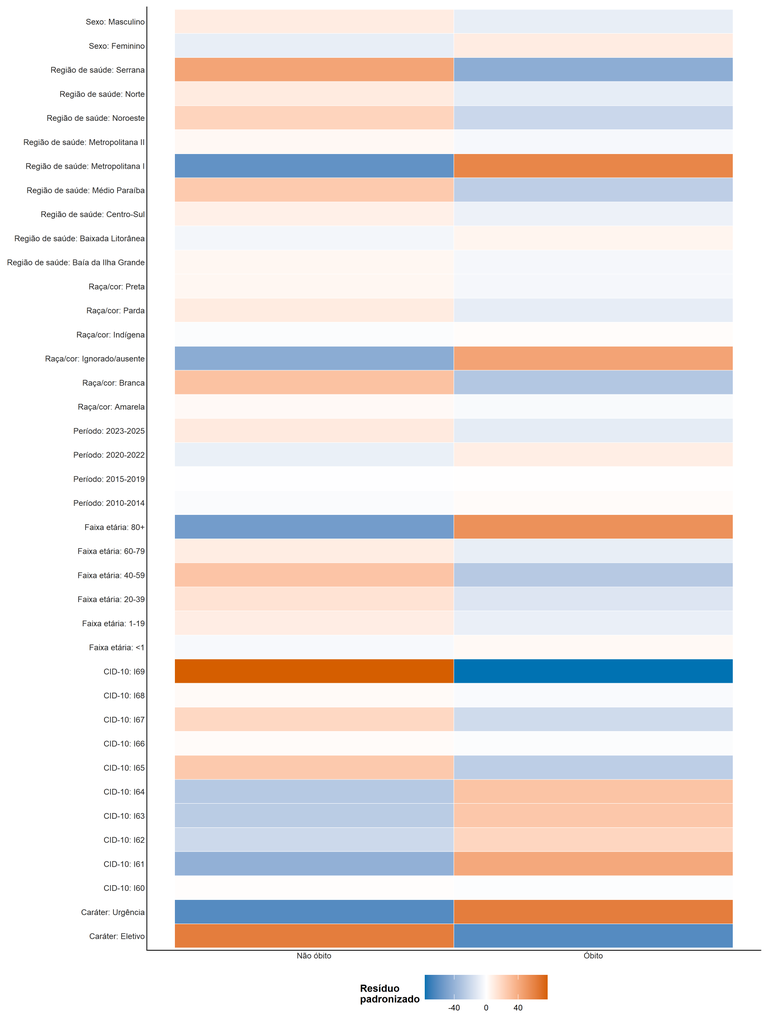

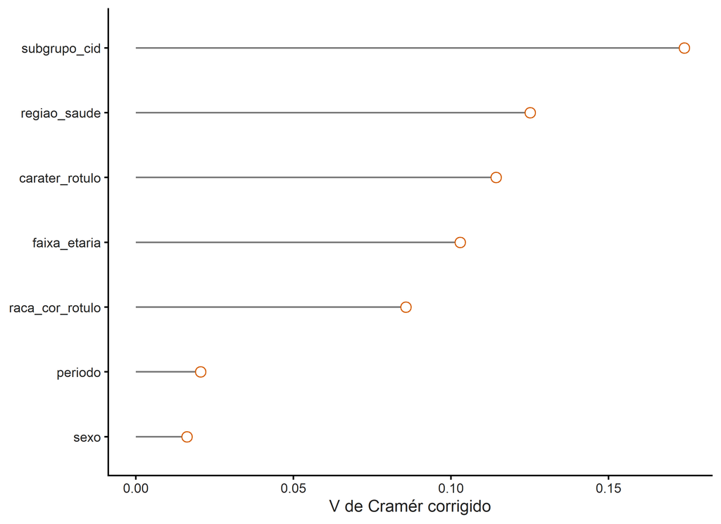

## Subgrupos CID-10

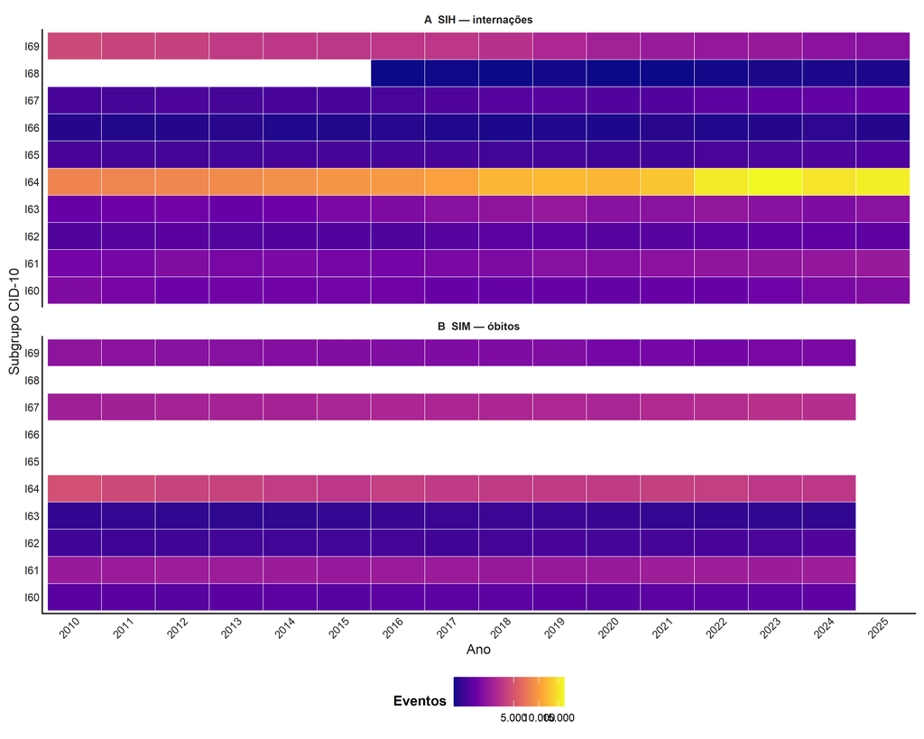

I60–I69 inclui eventos agudos, outras doenças cerebrovasculares e sequelas. A comparação de I69 separadamente permanece recomendada como análise de sensibilidade.

## Padrão gráfico

As figuras foram exportadas separadamente em PDF vetorial, TIFF RGB a 500 dpi e PNG RGB a 500 dpi. Foi usada paleta acessível a deficiências de visão de cores, contraste alto, fonte sem serifa equivalente a Arial/Helvetica e legendas em arquivo separado. A conformidade técnica não substitui a consulta ao guia do periódico Cell Press escolhido.

## Limitações inferenciais

- séries anuais curtas reduzem a potência e a precisão dos testes de tendência;
- autocorrelação residual pode afetar o Mann–Kendall convencional;
- comparações municipais não ajustam composição etária, oferta assistencial ou dependência espacial;
- qui-quadrado é análise bruta, sem controle de confundimento;
- SIH e SIM mensuram eventos distintos e não foram integrados entre si;
- custos do SIH são nominais, sem correção inflacionária;
- o SIM 2025 e as taxas de 2023 permanecem indisponíveis.